# Code Appendix - Childhood Asthma Management Program Project - BSTA 519

Matthew Hoctor, Bryon Langford

11/30/2021

# CAMP dataset

## Data import

Import the CAMP dataset:

```r
camp <- read_excel("camp_2021 class project.xlsx")
```

## Filling missing values

Fill missing covariate values and baseline:

```r
camp <- fill(camp, c("Anypet", "Woodstove", "Dehumid", "Parent_smokes", "FFratio"), .direction = "downup")
```

## Factoring & re-leveling

Relevel Treatment groups:

```r
camp$Trtment[camp$Trtment == "A"] <- "2budesonide"
camp$Trtment[camp$Trtment == "B"] <- "1nedocromil"
camp$Trtment[camp$Trtment == "C"] <- "0placebo"
```

Factor gender variable, and factor and re-level ethnicity variable:

```r
camp$Gender <- factor(camp$Gender)
camp$Ethnic <- factor(camp$Ethnic)
camp$Ethnic <- relevel(camp$Ethnic, ref = "w")
```

Relevel environmental variables (pet, woodstove, and parental smoking) such that 0=“no” and 1=“yes”:

```r
camp$Anypet[camp$Anypet == 2] <- 0
camp$Woodstove[camp$Woodstove == 2] <- 0
camp$Parent_smokes[camp$Parent_smokes == 2] <- 0
```

Relevel dehumidifier variable:

```r
camp$Dehumid[camp$Dehumid == 2] <- 0
```

Convert Dehumidifier variable to factor:

```r
# camp$Dehumid <- factor(camp$Dehumid)
```

Convert visit month variable to numeric:

```r
camp$Visitc <- as.numeric(camp$Visitc)
```

## Creating variables for baseline values

Adding baseline values of FFratio and environmental exposures dataset; NA values will be filled:

```r
for (i in 1:length(camp$id)) {
  camp$BFFratio[i] <- ifelse(camp$Visitc[i] == 0, camp$FFratio[i], NA)
  camp$BAnypet[i] <- ifelse(camp$Visitc[i] == 0, camp$Anypet[i], NA)
  camp$BWoodstove[i] <- ifelse(camp$Visitc[i] == 0, camp$Woodstove[i], NA)
  camp$BDehumid[i] <- ifelse(camp$Visitc[i] == 0, camp$Dehumid[i], NA)
  camp$BParent_smokes[i] <- ifelse(camp$Visitc[i] == 0, camp$Parent_smokes[i], NA)
}
```

Filling in baseline values for subsequent data points:

```r
camp <- fill(camp, c("BFFratio", "BAnypet", "BWoodstove", "BDehumid", "BParent_smokes"), .direction = "down")
```

## Wide dataset

Create wide dataset with baseline FFratio variable:

```r
campW <- pivot_wider(
  camp,
  id_cols = c(id, Trtment, Age_rz, Gender, Ethnic, BAnypet, BWoodstove, BDehumid, BParent_smokes, BFFratio),
  names_from = Visitc,
  names_prefix = "m",
  values_from = FFratio)
```

## Baseline-Adjusted Long Dataset

```r
camp2 <- subset(camp,Visitc != 0)
```

# Descriptive Statistics

```r
summary(camp$FFratio)
```

```
##    Min. 1st Qu.  Median    Mean 3rd Qu.    Max.
##   37.00   74.00   80.00   78.93   85.00  100.00
```

```r
# Filled missing FFratio values fixed this:

# FFratio variable has 31 missing values
# Remove missing values
# camp <- na.omit(camp)
```

```r
table(camp$Ethnic)
```

```
##
##    w    b    h    o
## 6849 1267  973  858
```

```r
table(camp$Dehumid)
```

```
##
##    0    1    3
## 8717  939  291
```

# Baseline statistics

Modify campW variables for a better table:

```r
campW$BDehumid[campW$BDehumid == 3] <- NA

campW$GenderF[campW$Gender == "f"] <- 1
campW$GenderF[campW$Gender == "m"] <- 0

campW$Ethnic2[campW$Ethnic == "w"] <- "White"
campW$Ethnic2[campW$Ethnic == "b"] <- "Black"
campW$Ethnic2[campW$Ethnic == "h"] <- "Hispanic"
campW$Ethnic2[campW$Ethnic == "o"] <- "Other"

campW$Age_rz <- as.numeric(campW$Age_rz)

campW$Trtment[campW$Trtment == "1nedocromil"] <- "Nedocromil"
campW$Trtment[campW$Trtment == "0placebo"] <- "Placebo"
campW$Trtment[campW$Trtment == "2budesonide"] <- "Budesonide"
```

Create factored and re-leveled ethnicity variable

```r
campW$Ethnic2 <- factor(campW$Ethnic2)
campW$Ethnic2 <- relevel(campW$Ethnic2, ref = "White")
```

Try adding a random value to age to get it to display as an average:

```r
for (i in 1:length(campW)) {
  campW$Age_rz2[i] <- campW$Age_rz[i] +rnorm(1)/1000000
  campW$BFFratio2[i] <- campW$BFFratio[i] +rnorm(1)/1000000
}
```

## Table 1

```r
campW %>%
  select(Trtment, BFFratio2, Age_rz2, GenderF, Ethnic2, BAnypet, BWoodstove, BDehumid, BParent_smokes) %>%
  tbl_summary(
  by = Trtment,
  missing = "no",
  digits = list(
    Age_rz2 ~ 2,
    BFFratio2 ~ 2
  ),
  label = list(
    BFFratio2 ~ "FEV1/FVC Ratio",
    Age_rz2 ~ "Age",
    GenderF ~ "Female Gender",
    Ethnic2 ~ "Ethnicity",
    BAnypet ~ "Pet Exposure",
    BWoodstove ~ "Woodstove Exposure",
    BDehumid ~ "Dehumidifier Exposure",
    BParent_smokes ~ "Tobacco Smoke Exposure"
  ),
    statistic = list(
      all_continuous() ~ "{mean}",
      all_categorical() ~ "{n} ({p}%)"),
  ) %>%
  add_p()%>%
  modify_caption("**Table 1. Baseline Patient Characteristics**") %>%
  bold_labels()
```

**Table 1. Baseline Patient Characteristics**

[output not shown]

<sup>*1*</sup> Mean; n (%) <sup>*2*</sup> Kruskal-Wallis rank sum test; Pearson's Chi-squared test

## Plots

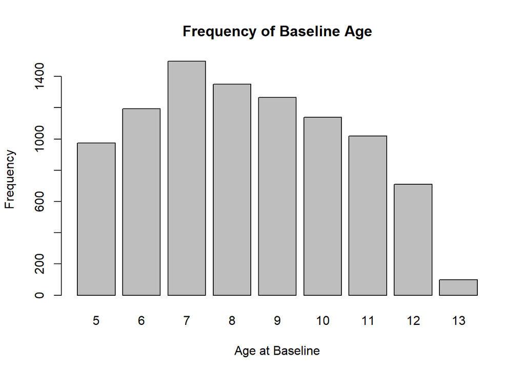

```r
barplot(table(camp2$Age_rz),
        main = "Frequency of Baseline Age",
        ylab = "Frequency",
        xlab = "Age at Baseline")
```

# Time Plot

```r
camp_mean <- camp %>%
  # na.omit() %>%       #Moved na.omit to the plotting section
  group_by(Trtment, Visitc) %>%
  summarise(Mean_FFratio = mean(FFratio), N = n())
camp_mean
```

```
## # A tibble: 60 x 4
## # Groups:   Trtment [3]
##    Trtment  Visitc Mean_FFratio     N
##    <chr>     <dbl>        <dbl> <int>
##  1 0placebo      0         80     275
##  2 0placebo      2         79.7   259
##  3 0placebo      4         79.0   265
##  4 0placebo     12         79.2   266
##  5 0placebo     16         78.8   261
##  6 0placebo     24         79.0   258
##  7 0placebo     28         78.7   251
##  8 0placebo     36         78.6   256
##  9 0placebo     40         78.4   250
## 10 0placebo     44         82       1
## # ... with 50 more rows
```

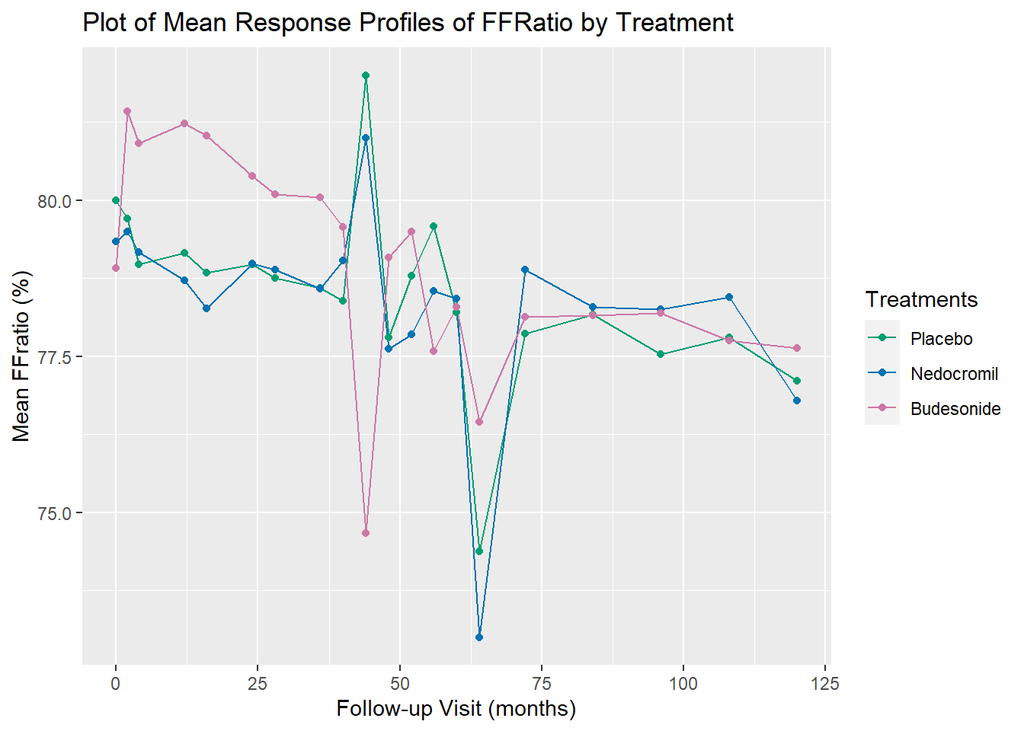

```r
ggplot(data = camp_mean,
       mapping = aes(x = Visitc, y = Mean_FFratio,
                     colour = factor(Trtment), group = factor(Trtment))) +
  geom_line() + geom_point() + theme(legend.position = "right") +
  labs(y = "Mean FFratio (%)", x = "Follow-up Visit (months)") +
  scale_color_manual(labels = c("Placebo", "Nedocromil", "Budesonide"), values =   c("#009E73", "#0072B2", "#CC79A7")) +
  ggtitle("Plot of Mean Response Profiles of FFRatio by Treatment") +
  labs(color = "Treatments")
```

Note that at month 44 there are 1, 6, & 3 observations for placebo, nedocromil, and budesonide respectively; and for month 64 there are 8, 2, & 9 observations for placebo, nedocromil, and budesonide respectively.

# Model Building

## Effectiveness of budesonide vs nedocromil

### RIRS Model

$$Y_{ij} = (\beta_0 + b_{1i}) + \beta_1 \mbox{Nedocromil}_{i} + \beta_2 \mbox{Budesonide}_{i} + (\beta_3 + b_{2i} + \beta_{11} \mbox{Nedocromil}_{i} + \beta_{12} \mbox{Budesonide}_{i})t_{ij} +\varepsilon_{ij}$$

```r
camp.RIRS.reduced <- lme(FFratio ~ Trtment*Fyears,
                   data = camp,
                   random = ~1+Fyears|id,
                   method = "REML",
                   na.action = na.omit
                   )
summary(camp.RIRS.reduced)
```

```
## Linear mixed-effects model fit by REML
##   Data: camp
##        AIC      BIC    logLik
##   59578.16 59650.21 -29779.08
##
## Random effects:
##  Formula: ~1 + Fyears | id
##  Structure: General positive-definite, Log-Cholesky parametrization
##             StdDev    Corr
## (Intercept) 7.3286133 (Intr)
## Fyears      0.7174282 -0.155
## Residual    4.0231993
##
## Fixed effects:  FFratio ~ Trtment * Fyears
##                              Value Std.Error   DF   t-value p-value
## (Intercept)               79.39603 0.4540861 9249 174.84796  0.0000
## Trtment1nedocromil        -0.36507 0.6899566  692  -0.52913  0.5969
## Trtment2budesonide         1.45761 0.6902920  692   2.11158  0.0351
## Fyears                    -0.18584 0.0505410 9249  -3.67694  0.0002
## Trtment1nedocromil:Fyears  0.09439 0.0772769 9249   1.22150  0.2219
## Trtment2budesonide:Fyears -0.18050 0.0770302 9249  -2.34323  0.0191
##  Correlation:
##                           (Intr) Trtmn1 Trtmn2 Fyears Trt1:F
## Trtment1nedocromil        -0.658
## Trtment2budesonide        -0.658  0.433
## Fyears                    -0.215  0.142  0.142
## Trtment1nedocromil:Fyears  0.141 -0.215 -0.093 -0.654
## Trtment2budesonide:Fyears  0.141 -0.093 -0.215 -0.656  0.429
##
## Standardized Within-Group Residuals:
##        Min         Q1        Med         Q3        Max
## -6.7050949 -0.4380185  0.0398134  0.5037537  4.6020855
##
## Number of Observations: 9947
## Number of Groups: 695
```

### RI Model

$$Y_{ij} = (\beta_0 + b_{1i}) + \beta_1 \mbox{Nedocromil}_{i} + \beta_2 \mbox{Budesonide}_{i} + (\beta_3 + \beta_{11} \mbox{Nedocromil}_{i} + \beta_{12} \mbox{Budesonide}_{i})t_{ij} +\varepsilon_{ij}$$

```r
camp.RI.reduced <- lme(FFratio ~ Trtment*Fyears,
                   data = camp,
                   random = ~1|id,
                   method = "REML",
                   na.action = na.omit
                   )
summary(camp.RI.reduced)
```

```
## Linear mixed-effects model fit by REML
##   Data: camp
##       AIC      BIC    logLik
##   60605.9 60663.54 -30294.95
##
## Random effects:
##  Formula: ~1 | id
##         (Intercept) Residual
## StdDev:    7.294374 4.479934
##
## Fixed effects:  FFratio ~ Trtment * Fyears
##                              Value Std.Error   DF   t-value p-value
## (Intercept)               79.40320 0.4546169 9249 174.65960  0.0000
## Trtment1nedocromil        -0.38172 0.6907472  692  -0.55261  0.5807
## Trtment2budesonide         1.45242 0.6911443  692   2.10147  0.0360
## Fyears                    -0.19103 0.0262526 9249  -7.27647  0.0000
## Trtment1nedocromil:Fyears  0.10111 0.0403249 9249   2.50729  0.0122
## Trtment2budesonide:Fyears -0.17710 0.0401633 9249  -4.40947  0.0000
##  Correlation:
##                           (Intr) Trtmn1 Trtmn2 Fyears Trt1:F
## Trtment1nedocromil        -0.658
## Trtment2budesonide        -0.658  0.433
## Fyears                    -0.191  0.125  0.125
## Trtment1nedocromil:Fyears  0.124 -0.189 -0.082 -0.651
## Trtment2budesonide:Fyears  0.125 -0.082 -0.190 -0.654  0.426
##
## Standardized Within-Group Residuals:
##         Min          Q1         Med          Q3         Max
## -6.00045229 -0.46375858  0.03977506  0.51506926  4.44427448
##
## Number of Observations: 9947
## Number of Groups: 695
```

Comparison to RIRS model:

```r
anova(camp.RI.reduced, camp.RIRS.reduced)
```

```
##                   Model df      AIC      BIC    logLik   Test  L.Ratio p-value
## camp.RI.reduced       1  8 60605.90 60663.54 -30294.95
## camp.RIRS.reduced     2 10 59578.16 59650.21 -29779.08 1 vs 2 1031.744  <.0001
```

From Fitzmaurice Table C1, for $q = 1$, a critical value of 14.18 corresponds to p=0.0005; therefore the RIRS model is a better fit.

### Baseline-adjusted RIRS model

$$Y_{ij} = (\beta_0 + b_{1i}) + \beta_1 \mbox{Nedocromil}_{i} + \beta_2 \mbox{Budesonide}_{i} + (\beta_3 + b_{2i} + \beta_{11} \mbox{Nedocromil}_{i} + \beta_{12} \mbox{Budesonide}_{i})t_{ij} + \beta_4 \mbox{Base-FFratio}_i +\varepsilon_{ij}$$

```r
camp2.RIRS.reduced <- lme(FFratio ~ Trtment*Fyears + BFFratio,
                   data = camp2,
                   random = ~1+Fyears|id,
                   method = "REML",
                   na.action = na.omit
                   )
summary(camp2.RIRS.reduced)
```

```
## Linear mixed-effects model fit by REML
##   Data: camp2
##        AIC      BIC    logLik
##   54599.89 54678.34 -27288.94
##
## Random effects:
##  Formula: ~1 + Fyears | id
##  Structure: General positive-definite, Log-Cholesky parametrization
##             StdDev    Corr
## (Intercept) 4.1355942 (Intr)
## Fyears      0.7290081 -0.143
## Residual    3.9608113
##
## Fixed effects:  FFratio ~ Trtment * Fyears + BFFratio
##                               Value Std.Error   DF  t-value p-value
## (Intercept)               20.577039 1.6375848 8557 12.56548  0.0000
## Trtment1nedocromil         0.188117 0.4167813  688  0.45136  0.6519
## Trtment2budesonide         2.840829 0.4181949  688  6.79307  0.0000
## Fyears                    -0.160454 0.0517895 8557 -3.09820  0.0020
## BFFratio                   0.733550 0.0201872  688 36.33735  0.0000
## Trtment1nedocromil:Fyears  0.082260 0.0791816 8557  1.03888  0.2989
## Trtment2budesonide:Fyears -0.287980 0.0789442 8557 -3.64789  0.0003
##  Correlation:
##                           (Intr) Trtmn1 Trtmn2 Fyears BFFrat Trt1:F
## Trtment1nedocromil        -0.140
## Trtment2budesonide        -0.162  0.433
## Fyears                    -0.047  0.183  0.182
## BFFratio                  -0.986  0.030  0.053  0.001
## Trtment1nedocromil:Fyears  0.031 -0.277 -0.119 -0.654 -0.001
## Trtment2budesonide:Fyears  0.032 -0.120 -0.278 -0.656 -0.002  0.429
##
## Standardized Within-Group Residuals:
##         Min          Q1         Med          Q3         Max
## -6.71576530 -0.43326547  0.04210705  0.49923125  4.80073458
##
## Number of Observations: 9252
## Number of Groups: 692
```

### baseline-adjusted RI Model

$$Y_{ij} = (\beta_0 + b_{1i}) + \beta_1 \mbox{Nedocromil}_{i} + \beta_2 \mbox{Budesonide}_{i} + (\beta_3 + \beta_{11} \mbox{Nedocromil}_{i} + \beta_{12} \mbox{Budesonide}_{i})t_{ij} + \beta_4 \mbox{Base-FFratio}_i +\varepsilon_{ij}$$

```r
camp2.RI.reduced <- lme(FFratio ~ Trtment*Fyears + BFFratio,
                   data = camp2,
                   random = ~1|id,
                   method = "REML",
                   na.action = na.omit
                   )
summary(camp2.RI.reduced)
```

```
## Linear mixed-effects model fit by REML
##   Data: camp2
##        AIC     BIC    logLik
##   55621.32 55685.5 -27801.66
##
## Random effects:
##  Formula: ~1 | id
##         (Intercept) Residual
## StdDev:    4.497605  4.41697
##
## Fixed effects:  FFratio ~ Trtment * Fyears + BFFratio
##                               Value Std.Error   DF  t-value p-value
## (Intercept)               22.663423 1.7563771 8557 12.90351  0.0000
## Trtment1nedocromil         0.152058 0.4540468  688  0.33489  0.7378
## Trtment2budesonide         2.794225 0.4555464  688  6.13379  0.0000
## Fyears                    -0.167635 0.0274813 8557 -6.09996  0.0000
## BFFratio                   0.707605 0.0216415  688 32.69673  0.0000
## Trtment1nedocromil:Fyears  0.090135 0.0421733 8557  2.13725  0.0326
## Trtment2budesonide:Fyears -0.274960 0.0420431 8557 -6.53995  0.0000
##  Correlation:
##                           (Intr) Trtmn1 Trtmn2 Fyears BFFrat Trt1:F
## Trtment1nedocromil        -0.141
## Trtment2budesonide        -0.163  0.433
## Fyears                    -0.058  0.216  0.216
## BFFratio                  -0.985  0.029  0.052  0.002
## Trtment1nedocromil:Fyears  0.037 -0.326 -0.140 -0.652 -0.001
## Trtment2budesonide:Fyears  0.039 -0.141 -0.328 -0.654 -0.003  0.426
##
## Standardized Within-Group Residuals:
##         Min          Q1         Med          Q3         Max
## -6.01743077 -0.46785405  0.03789995  0.51464780  4.56337865
##
## Number of Observations: 9252
## Number of Groups: 692
```

Comparison to RIRS model:

```r
anova(camp2.RI.reduced, camp2.RIRS.reduced)
```

```
##                    Model df      AIC      BIC    logLik   Test L.Ratio p-value
## camp2.RI.reduced       1  9 55621.32 55685.50 -27801.66
## camp2.RIRS.reduced     2 11 54599.89 54678.34 -27288.94 1 vs 2 1025.43  <.0001
```

```r
anova(camp.RI.reduced, camp.RIRS.reduced)
```

```
##                   Model df      AIC      BIC    logLik   Test  L.Ratio p-value
## camp.RI.reduced       1  8 60605.90 60663.54 -30294.95
## camp.RIRS.reduced     2 10 59578.16 59650.21 -29779.08 1 vs 2 1031.744  <.0001
```

### Change over time in FEV1/FVC ratio

#### Placebo

Starting with the baseline-adjusted RIRS model; we can test $H_0: \beta_3 = 0$:

```r
B3 = c(0,0,0,1,0,0,0)
anova(camp2.RIRS.reduced, L = B3)
```

```
## F-test for linear combination(s)
## [1] 1
##   numDF denDF  F-value p-value
## 1     1  8557 9.598855   0.002
```

Therefore we can conclude that there is a change over time in FEV1/FVC ratio for the placebo group.

#### Nedocromil

Starting with the baseline-adjusted RIRS model; we can test $H_0: \beta_3 + \beta_{11}= 0$:

```r
B3B11 = c(0,0,0,1,0,1,0)
anova(camp2.RIRS.reduced, L = B3B11)
```

```
## F-test for linear combination(s)
##                    Fyears Trtment1nedocromil:Fyears
##                         1                         1
##   numDF denDF  F-value p-value
## 1     1  8557 1.704309  0.1918
```

Therefore we fail to reject the null hypothesis; the change over time in FEV1/FVC ratio for the nedocromil group is not statistically significantly different from the null.

#### Budesonide

Starting with the baseline-adjusted RIRS model; we can test $H_0: \beta_3 + \beta_{12} = 0$:

```r
B3B12 = c(0,0,0,1,0,0,1)
anova(camp2.RIRS.reduced, L = B3B12)
```

```
## F-test for linear combination(s)
##                    Fyears Trtment2budesonide:Fyears
##                         1                         1
##   numDF denDF  F-value p-value
## 1     1  8557 56.64554  <.0001
```

Therefore we can conclude that there is a change over time in FEV1/FVC ratio for the budesonide group.

### Effectiveness of budesonide and nedocromil in preventing decline of FFratio

We can first start with the null hypothesis that neither treatment is effective; $H_0: \beta_{11} = \beta_{12} = 0$:

```r
B11 = c(0,0,0,0,0,1,0)
B12 = c(0,0,0,0,0,0,1)
anova(camp2.RIRS.reduced, L = rbind(B11, B12))
```

```
## F-test for linear combination(s)
##     Trtment1nedocromil:Fyears Trtment2budesonide:Fyears
## B11                         1                         0
## B12                         0                         1
##   numDF denDF  F-value p-value
## 1     2  8557 10.80941  <.0001
```

We can now test each individually:

```r
anova(camp2.RIRS.reduced, L = B11)
```

```
## F-test for linear combination(s)
## [1] 1
##   numDF denDF  F-value p-value
## 1     1  8557 1.079268  0.2989
```

```r
anova(camp2.RIRS.reduced, L = B12)
```

```
## F-test for linear combination(s)
## [1] 1
##   numDF denDF  F-value p-value
## 1     1  8557 13.30709   3e-04
```

Therefore nedocromil does not significantly prevent decline of FFratio, but budesonide does have a statistically significant effect on decline in FFratio

### Difference in effectiveness of budesonide vs nedocromil

To test differences in effectiveness of budesonide vs nedocromil we can test differences in immediate effect and effect over time; to test if there is a difference in immediate effect we will test $H_0: \beta_1 - \beta_2 = 0$:

```r
B1B2 = c(0,1,-1,0,0,0,0)
anova(camp2.RIRS.reduced, L = B1B2)
```

```
## F-test for linear combination(s)
## Trtment1nedocromil Trtment2budesonide
##                  1                 -1
##   numDF denDF  F-value p-value
## 1     1   688 35.61702  <.0001
```

We find a significant difference in immediate effect. To test effect over time, we can test $H_0: \beta_{11} - \beta_{12} = 0$:

```r
B11B12 = c(0,0,0,0,0,1,-1)
anova(camp2.RIRS.reduced, L = B11B12)
```

```
## F-test for linear combination(s)
## Trtment1nedocromil:Fyears Trtment2budesonide:Fyears
##                         1                        -1
##   numDF denDF  F-value p-value
## 1     1  8557 19.20498  <.0001
```

We also find a significant difference in effect over time.

### Parameter interpretation of baseline-adjusted RIRS model:

```r
summary(camp2.RIRS.reduced)
```

```
## Linear mixed-effects model fit by REML
##   Data: camp2
##        AIC      BIC    logLik
##   54599.89 54678.34 -27288.94
##
## Random effects:
##  Formula: ~1 + Fyears | id
##  Structure: General positive-definite, Log-Cholesky parametrization
##             StdDev    Corr
## (Intercept) 4.1355942 (Intr)
## Fyears      0.7290081 -0.143
## Residual    3.9608113
##
## Fixed effects:  FFratio ~ Trtment * Fyears + BFFratio
##                               Value Std.Error   DF  t-value p-value
## (Intercept)               20.577039 1.6375848 8557 12.56548  0.0000
## Trtment1nedocromil         0.188117 0.4167813  688  0.45136  0.6519
## Trtment2budesonide         2.840829 0.4181949  688  6.79307  0.0000
## Fyears                    -0.160454 0.0517895 8557 -3.09820  0.0020
## BFFratio                   0.733550 0.0201872  688 36.33735  0.0000
## Trtment1nedocromil:Fyears  0.082260 0.0791816 8557  1.03888  0.2989
## Trtment2budesonide:Fyears -0.287980 0.0789442 8557 -3.64789  0.0003
##  Correlation:
##                           (Intr) Trtmn1 Trtmn2 Fyears BFFrat Trt1:F
## Trtment1nedocromil        -0.140
## Trtment2budesonide        -0.162  0.433
## Fyears                    -0.047  0.183  0.182
## BFFratio                  -0.986  0.030  0.053  0.001
## Trtment1nedocromil:Fyears  0.031 -0.277 -0.119 -0.654 -0.001
## Trtment2budesonide:Fyears  0.032 -0.120 -0.278 -0.656 -0.002  0.429
##
## Standardized Within-Group Residuals:
##         Min          Q1         Med          Q3         Max
## -6.71576530 -0.43326547  0.04210705  0.49923125  4.80073458
##
## Number of Observations: 9252
## Number of Groups: 692
```

```r
intervals(camp2.RIRS.reduced, method = "Wald")
```

```
## Approximate 95% confidence intervals
##
##  Fixed effects:
##                                 lower        est.       upper
## (Intercept)               17.36697813 20.57703940 23.78710066
## Trtment1nedocromil        -0.63019931  0.18811655  1.00643241
## Trtment2budesonide         2.01973722  2.84082862  3.66192002
## Fyears                    -0.26197415 -0.16045427 -0.05893439
## BFFratio                   0.69391447  0.73355044  0.77318640
## Trtment1nedocromil:Fyears -0.07295502  0.08226005  0.23747511
## Trtment2budesonide:Fyears -0.44272912 -0.28797952 -0.13322992
## attr(,"label")
## [1] "Fixed effects:"
##
##  Random Effects:
##   Level: id
##                              lower       est.       upper
## sd((Intercept))          3.8812166  4.1355942  4.40664381
## sd(Fyears)               0.6776535  0.7290081  0.78425445
## cor((Intercept),Fyears) -0.2335680 -0.1430639 -0.05010212
##
##  Within-group standard error:
##    lower     est.    upper
## 3.899451 3.960811 4.023137
```

Intercept 95% CI

```r
EST <- 20.57703940
SD <- 4.1355942
UB <- EST + SD*1.96
UB
```

```
## [1] 28.6828
```

```r
LB <- EST - SD*1.96
LB
```

```
## [1] 12.47127
```

Therefore 95% of subjects will have an intercept ($\beta_0 + b_1i$) within (12.47,28.68).

Slope 95% CI

```r
EST <- -0.16045427
SD <- 0.7290081
UB <- EST + SD*1.96
UB
```

```
## [1] 1.268402
```

```r
LB <- EST - SD*1.96
LB
```

```
## [1] -1.58931
```

Therefore 95% of subjects will have a slope ($\beta_3 + b_2i$) within (-1.59,1.27).

## Patient characteristics-adjusted associations with FFratio

$$Y_{ij} = (\beta_0 + b_{1i}) + \beta_1 \mbox{Nedocromil}_{i} + \beta_2 \mbox{Budesonide}_{i} + (\beta_3 + b_{2i} + \beta_{11} \mbox{Nedocromil}_{i} + \beta_{12} \mbox{Budesonide}_{i})t_{ij} +\beta_4 \mbox{Gender}_i +\beta_5 \mbox{Ethnicity}_i +\beta_6 \mbox{Pet}_i +\beta_7 \mbox{Woodstove}_i +\beta_8 \mbox{Dehumidifier}_i + \beta_9 \mbox{Base-FFratio}_i +\varepsilon_{ij}$$

$$\begin{align*}
Y_{ij} &= (\beta_0 + b_{1i}) + \beta_1 \mbox{Nedocromil}_{i} + \beta_2 \mbox{Budesonide}_{i}\\
&\quad+ (\beta_3 + b_{2i} + \beta_{11} \mbox{Nedocromil}_{i} + \beta_{12} \mbox{Budesonide}_{i})t_{ij}\\
&\quad+\beta_4 \mbox{Gender}_i +\beta_5 \mbox{Ethnicity}_i + \beta_6 \mbox{Base-Age}_i\\
&\quad+ \beta_7 \mbox{Smoke}_{ij} + \beta_8 \mbox{Pet}_{ij} +\beta_9 \mbox{Woodstove}_{ij} +\beta_{10} \mbox{Dehumidifier}_{ij} + \beta_{11} \mbox{Base-FEV1/FVC}_{ij} +\varepsilon_{ij}
\end{align*}$$

```r
camp2.RIRS.full <- lme(FFratio ~ Trtment*Fyears + Age_rz + Gender + Ethnic + Anypet + Woodstove + Dehumid + Parent_smokes + BFFratio,
                   data = camp2,
                   random = ~1+Fyears|id,
                   method = "REML",
                   na.action = na.omit
                   )
summary(camp2.RIRS.full)
```

```
## Linear mixed-effects model fit by REML
##   Data: camp2
##        AIC      BIC    logLik
##   54620.27 54762.89 -27290.14
##
## Random effects:
##  Formula: ~1 + Fyears | id
##  Structure: General positive-definite, Log-Cholesky parametrization
##             StdDev    Corr
## (Intercept) 4.1487266 (Intr)
## Fyears      0.7293092 -0.144
## Residual    3.9609338
##
## Fixed effects:  FFratio ~ Trtment * Fyears + Age_rz + Gender + Ethnic + Anypet +      Woodstove + Dehumid + Parent_smokes + BFFratio
##                               Value Std.Error   DF  t-value p-value
## (Intercept)               20.507907 1.7928993 8553 11.43840  0.0000
## Trtment1nedocromil         0.180682 0.4204561  683  0.42973  0.6675
## Trtment2budesonide         2.825486 0.4204958  683  6.71942  0.0000
## Fyears                    -0.158680 0.0518349 8553 -3.06125  0.0022
## Age_rz                     0.008691 0.0777011  683  0.11185  0.9110
## Genderm                    0.128074 0.3422972  683  0.37416  0.7084
## Ethnicb                    0.348553 0.5054176  683  0.68963  0.4907
## Ethnich                   -0.578682 0.5678931  683 -1.01900  0.3086
## Ethnico                    0.176952 0.6058635  683  0.29207  0.7703
## Anypet                    -0.243485 0.1894701 8553 -1.28509  0.1988
## Woodstove                  0.240029 0.3445581 8553  0.69663  0.4861
## Dehumid                   -0.052773 0.1139364 8553 -0.46318  0.6432
## Parent_smokes              0.149769 0.2431206 8553  0.61603  0.5379
## BFFratio                   0.734182 0.0202817  683 36.19921  0.0000
## Trtment1nedocromil:Fyears  0.082518 0.0792241 8553  1.04157  0.2976
## Trtment2budesonide:Fyears -0.289758 0.0789843 8553 -3.66856  0.0002
##  Correlation:
##                           (Intr) Trtmn1 Trtmn2 Fyears Age_rz Gendrm Ethncb
## Trtment1nedocromil        -0.116
## Trtment2budesonide        -0.131  0.436
## Fyears                    -0.045  0.181  0.181
## Age_rz                    -0.386 -0.004 -0.031  0.001
## Genderm                   -0.101 -0.106 -0.056  0.001  0.071
## Ethnicb                   -0.042 -0.007 -0.009  0.000 -0.033 -0.010
## Ethnich                   -0.054 -0.020 -0.010  0.002  0.038 -0.055  0.140
```

[output cut: 32 more lines]

```
## Ethnico
## Anypet
## Woodstove
## Dehumid
## Parent_smokes
## BFFratio
## Trtment1nedocromil:Fyears
## Trtment2budesonide:Fyears  0.429
##
## Standardized Within-Group Residuals:
##         Min          Q1         Med          Q3         Max
## -6.71733790 -0.43547717  0.04304627  0.49746173  4.78994112
##
## Number of Observations: 9252
## Number of Groups: 692
```

It is interesting to note that treatment effects seem to have similar values in the full model.

### Deletion 1

Given the above results, we can consider removing age from the above model:

```r
camp2.RIRS.1 <- lme(FFratio ~ Trtment*Fyears + Gender + Ethnic + Anypet + Woodstove + Dehumid + Parent_smokes + BFFratio,
                   data = camp2,
                   random = ~1+Fyears|id,
                   method = "REML",
                   na.action = na.omit
                   )
summary(camp2.RIRS.1)
```

```
## Linear mixed-effects model fit by REML
##   Data: camp2
##        AIC     BIC    logLik
##   54615.01 54750.5 -27288.51
##
## Random effects:
##  Formula: ~1 + Fyears | id
##  Structure: General positive-definite, Log-Cholesky parametrization
##             StdDev    Corr
## (Intercept) 4.1454270 (Intr)
## Fyears      0.7293081 -0.144
## Residual    3.9609345
##
## Fixed effects:  FFratio ~ Trtment * Fyears + Gender + Ethnic + Anypet + Woodstove +      Dehumid + Parent_smokes + BFFratio
##                               Value Std.Error   DF  t-value p-value
## (Intercept)               20.585425 1.6530302 8553 12.45314  0.0000
## Trtment1nedocromil         0.180891 0.4201734  684  0.43052  0.6670
## Trtment2budesonide         2.826940 0.4200176  684  6.73053  0.0000
## Fyears                    -0.158684 0.0518347 8553 -3.06135  0.0022
## Genderm                    0.125399 0.3411922  684  0.36753  0.7133
## Ethnicb                    0.350377 0.5047814  684  0.69412  0.4878
## Ethnich                   -0.581098 0.5670660  684 -1.02475  0.3058
## Ethnico                    0.180812 0.6044561  684  0.29913  0.7649
## Anypet                    -0.243151 0.1894137 8553 -1.28371  0.1993
## Woodstove                  0.239994 0.3444975 8553  0.69665  0.4860
## Dehumid                   -0.052877 0.1139266 8553 -0.46413  0.6426
## Parent_smokes              0.149119 0.2430029 8553  0.61365  0.5395
## BFFratio                   0.734130 0.0202621  684 36.23163  0.0000
## Trtment1nedocromil:Fyears  0.082516 0.0792239 8553  1.04155  0.2976
## Trtment2budesonide:Fyears -0.289752 0.0789841 8553 -3.66848  0.0002
##  Correlation:
##                           (Intr) Trtmn1 Trtmn2 Fyears Gendrm Ethncb Ethnch
## Trtment1nedocromil        -0.127
## Trtment2budesonide        -0.155  0.436
## Fyears                    -0.048  0.181  0.181
## Genderm                   -0.080 -0.106 -0.054  0.001
## Ethnicb                   -0.059 -0.007 -0.010  0.000 -0.008
## Ethnich                   -0.043 -0.020 -0.009  0.002 -0.058  0.142
## Ethnico                   -0.005 -0.010 -0.039  0.001 -0.029  0.132  0.119
## Anypet                    -0.040 -0.002  0.004 -0.011 -0.003  0.001  0.005
```

[output cut: 13 more lines]

```
## Ethnico
## Anypet                    -0.022
## Woodstove                  0.023 -0.042
## Dehumid                    0.004  0.018 -0.009
## Parent_smokes             -0.003 -0.040  0.009 -0.005
## BFFratio                  -0.027 -0.041  0.002  0.004 -0.003
## Trtment1nedocromil:Fyears -0.001 -0.012  0.000  0.009 -0.014  0.000
## Trtment2budesonide:Fyears  0.000  0.012  0.001  0.002 -0.015 -0.002  0.429
##
## Standardized Within-Group Residuals:
##         Min          Q1         Med          Q3         Max
## -6.71821789 -0.43507547  0.04291276  0.49748318  4.78890755
##
## Number of Observations: 9252
## Number of Groups: 692
```

We can compare the fit of the reduced model

```r
anova(camp2.RIRS.full, camp2.RIRS.1)
```

```
##                 Model df      AIC      BIC    logLik   Test  L.Ratio p-value
## camp2.RIRS.full     1 20 54620.27 54762.89 -27290.14
## camp2.RIRS.1        2 19 54615.01 54750.50 -27288.51 1 vs 2 3.260106   0.071
```

The models have similar fit; therefore we can proceed with the next deletion step.

### Deletion 2

```r
camp2.RIRS.2 <- lme(FFratio ~ Trtment*Fyears + Ethnic + Anypet + Woodstove + Dehumid + Parent_smokes + BFFratio,
                   data = camp2,
                   random = ~1+Fyears|id,
                   method = "REML",
                   na.action = na.omit
                   )
summary(camp2.RIRS.2)
```

```
## Linear mixed-effects model fit by REML
##   Data: camp2
##        AIC      BIC    logLik
##   54612.83 54741.19 -27288.42
##
## Random effects:
##  Formula: ~1 + Fyears | id
##  Structure: General positive-definite, Log-Cholesky parametrization
##             StdDev    Corr
## (Intercept) 4.1415330 (Intr)
## Fyears      0.7293222 -0.143
## Residual    3.9609224
##
## Fixed effects:  FFratio ~ Trtment * Fyears + Ethnic + Anypet + Woodstove + Dehumid +      Parent_smokes + BFFratio
##                               Value Std.Error   DF  t-value p-value
## (Intercept)               20.630226 1.6467596 8553 12.52777  0.0000
## Trtment1nedocromil         0.197352 0.4174715  685  0.47273  0.6366
## Trtment2budesonide         2.835396 0.4190728  685  6.76588  0.0000
## Fyears                    -0.158696 0.0518354 8553 -3.06153  0.0022
## Ethnicb                    0.352084 0.5044587  685  0.69794  0.4854
## Ethnich                   -0.569306 0.5657568  685 -1.00627  0.3146
## Ethnico                    0.186712 0.6038358  685  0.30921  0.7573
## Anypet                    -0.242945 0.1893894 8553 -1.28278  0.1996
## Woodstove                  0.241061 0.3444087 8553  0.69993  0.4840
## Dehumid                   -0.053468 0.1139055 8553 -0.46941  0.6388
## Parent_smokes              0.148898 0.2429422 8553  0.61289  0.5400
## BFFratio                   0.734382 0.0202420  685 36.28018  0.0000
## Trtment1nedocromil:Fyears  0.082536 0.0792251 8553  1.04180  0.2975
## Trtment2budesonide:Fyears -0.289736 0.0789852 8553 -3.66823  0.0002
##  Correlation:
##                           (Intr) Trtmn1 Trtmn2 Fyears Ethncb Ethnch Ethnic
## Trtment1nedocromil        -0.137
## Trtment2budesonide        -0.160  0.433
## Fyears                    -0.048  0.182  0.181
## Ethnicb                   -0.060 -0.008 -0.010  0.000
## Ethnich                   -0.048 -0.026 -0.012  0.002  0.142
## Ethnico                   -0.008 -0.013 -0.040  0.001  0.132  0.118
## Anypet                    -0.041 -0.002  0.004 -0.011  0.001  0.005 -0.022
## Woodstove                 -0.016 -0.003  0.000  0.007  0.013  0.021  0.022
## Dehumid                   -0.017 -0.008 -0.006  0.000 -0.016 -0.004  0.005
```

[output cut: 10 more lines]

```
## Ethnico
## Anypet
## Woodstove                 -0.042
## Dehumid                    0.018 -0.008
## Parent_smokes             -0.040  0.009 -0.005
## BFFratio                  -0.041  0.001  0.004 -0.003
## Trtment1nedocromil:Fyears -0.012  0.000  0.009 -0.014  0.000
## Trtment2budesonide:Fyears  0.012  0.001  0.002 -0.015 -0.002  0.429
##
## Standardized Within-Group Residuals:
##         Min          Q1         Med          Q3         Max
## -6.71738457 -0.43557096  0.04312153  0.49767006  4.78637661
##
## Number of Observations: 9252
## Number of Groups: 692
```

We can compare the fit of the reduced model

```r
anova(camp2.RIRS.1, camp2.RIRS.2)
```

```
##              Model df      AIC      BIC    logLik   Test   L.Ratio p-value
## camp2.RIRS.1     1 19 54615.01 54750.50 -27288.51
## camp2.RIRS.2     2 18 54612.83 54741.19 -27288.42 1 vs 2 0.1786271  0.6726
```

The models have similar fit; therefore we can proceed with the next deletion step.

### Deletion 3

Given the above results, we can consider removing dehumidifier exposure from the above model:

```r
camp2.RIRS.3 <- lme(FFratio ~ Trtment*Fyears + Ethnic + Anypet + Woodstove + Parent_smokes + BFFratio,
                   data = camp2,
                   random = ~1+Fyears|id,
                   method = "REML",
                   na.action = na.omit
                   )
summary(camp2.RIRS.3)
```

```
## Linear mixed-effects model fit by REML
##   Data: camp2
##        AIC      BIC    logLik
##   54608.55 54729.78 -27287.27
##
## Random effects:
##  Formula: ~1 + Fyears | id
##  Structure: General positive-definite, Log-Cholesky parametrization
##             StdDev    Corr
## (Intercept) 4.1408010 (Intr)
## Fyears      0.7292056 -0.143
## Residual    3.9607838
##
## Fixed effects:  FFratio ~ Trtment * Fyears + Ethnic + Anypet + Woodstove + Parent_smokes +      BFFratio
##                               Value Std.Error   DF  t-value p-value
## (Intercept)               20.615468 1.6464518 8554 12.52115  0.0000
## Trtment1nedocromil         0.195725 0.4173926  685  0.46892  0.6393
## Trtment2budesonide         2.834254 0.4190012  685  6.76431  0.0000
## Fyears                    -0.158682 0.0518288 8554 -3.06167  0.0022
## Ethnicb                    0.348344 0.5043703  685  0.69065  0.4900
## Ethnich                   -0.570402 0.5657293  685 -1.00826  0.3137
## Ethnico                    0.187875 0.6038026  685  0.31115  0.7558
## Anypet                    -0.241338 0.1893493 8554 -1.27457  0.2025
## Woodstove                  0.239526 0.3443734 8554  0.69554  0.4867
## Parent_smokes              0.148370 0.2429251 8554  0.61076  0.5414
## BFFratio                   0.734444 0.0202409  685 36.28515  0.0000
## Trtment1nedocromil:Fyears  0.082859 0.0792119 8554  1.04604  0.2956
## Trtment2budesonide:Fyears -0.289654 0.0789748 8554 -3.66768  0.0002
##  Correlation:
##                           (Intr) Trtmn1 Trtmn2 Fyears Ethncb Ethnch Ethnic
## Trtment1nedocromil        -0.137
## Trtment2budesonide        -0.160  0.433
## Fyears                    -0.048  0.182  0.181
## Ethnicb                   -0.060 -0.008 -0.010  0.000
## Ethnich                   -0.048 -0.026 -0.012  0.002  0.142
## Ethnico                   -0.008 -0.013 -0.040  0.001  0.132  0.118
## Anypet                    -0.040 -0.002  0.004 -0.011  0.001  0.005 -0.022
## Woodstove                 -0.017 -0.003  0.000  0.007  0.013  0.021  0.022
## Parent_smokes             -0.035 -0.005 -0.007  0.031  0.017  0.020 -0.003
## BFFratio                  -0.980  0.030  0.053  0.001  0.013  0.006 -0.028
## Trtment1nedocromil:Fyears  0.032 -0.276 -0.119 -0.654 -0.001 -0.001 -0.001
## Trtment2budesonide:Fyears  0.032 -0.119 -0.277 -0.656 -0.001 -0.001 -0.001
##                           Anypet Wodstv Prnt_s BFFrat Trt1:F
## Trtment1nedocromil
## Trtment2budesonide
## Fyears
## Ethnicb
## Ethnich
## Ethnico
## Anypet
## Woodstove                 -0.042
## Parent_smokes             -0.040  0.009
## BFFratio                  -0.041  0.001 -0.003
## Trtment1nedocromil:Fyears -0.012  0.000 -0.014  0.000
## Trtment2budesonide:Fyears  0.012  0.001 -0.015 -0.002  0.429
##
## Standardized Within-Group Residuals:
##        Min         Q1        Med         Q3        Max
## -6.7174937 -0.4337494  0.0428575  0.4978782  4.7872981
##
## Number of Observations: 9252
## Number of Groups: 692
```

We can compare the fit of the reduced model

```r
anova(camp2.RIRS.2, camp2.RIRS.3)
```

```
##              Model df      AIC      BIC    logLik   Test  L.Ratio p-value
## camp2.RIRS.2     1 18 54612.83 54741.19 -27288.42
## camp2.RIRS.3     2 17 54608.55 54729.78 -27287.27 1 vs 2 2.286699  0.1305
```

The models have similar fit; therefore we can proceed with the next deletion step.

### Deletion 4

Given the above results, we can consider removing secondhand smoke exposure from the above model:

```r
camp2.RIRS.4 <- lme(FFratio ~ Trtment*Fyears + Ethnic + Anypet + Woodstove + BFFratio,
                   data = camp2,
                   random = ~1+Fyears|id,
                   method = "REML",
                   na.action = na.omit
                   )
summary(camp2.RIRS.4)
```

```
## Linear mixed-effects model fit by REML
##   Data: camp2
##        AIC      BIC    logLik
##   54605.93 54720.03 -27286.96
##
## Random effects:
##  Formula: ~1 + Fyears | id
##  Structure: General positive-definite, Log-Cholesky parametrization
##             StdDev    Corr
## (Intercept) 4.1398864 (Intr)
## Fyears      0.7291945 -0.143
## Residual    3.9607507
##
## Fixed effects:  FFratio ~ Trtment * Fyears + Ethnic + Anypet + Woodstove + BFFratio
##                               Value Std.Error   DF  t-value p-value
## (Intercept)               20.652879 1.6448840 8555 12.55583  0.0000
## Trtment1nedocromil         0.197077 0.4173093  685  0.47226  0.6369
## Trtment2budesonide         2.836088 0.4189123  685  6.77012  0.0000
## Fyears                    -0.159673 0.0518029 8555 -3.08231  0.0021
## Ethnicb                    0.342984 0.5041220  685  0.68036  0.4965
## Ethnich                   -0.577241 0.5654131  685 -1.02092  0.3077
## Ethnico                    0.189389 0.6035887  685  0.31377  0.7538
## Anypet                    -0.236804 0.1891885 8555 -1.25168  0.2107
## Woodstove                  0.237740 0.3443359 8555  0.69043  0.4899
## BFFratio                   0.734454 0.0202338  685 36.29846  0.0000
## Trtment1nedocromil:Fyears  0.083516 0.0792034 8555  1.05445  0.2917
## Trtment2budesonide:Fyears -0.288919 0.0789644 8555 -3.65885  0.0003
##  Correlation:
##                           (Intr) Trtmn1 Trtmn2 Fyears Ethncb Ethnch Ethnic
## Trtment1nedocromil        -0.138
## Trtment2budesonide        -0.160  0.433
## Fyears                    -0.047  0.182  0.182
## Ethnicb                   -0.060 -0.008 -0.010  0.000
## Ethnich                   -0.047 -0.026 -0.012  0.001  0.141
## Ethnico                   -0.008 -0.013 -0.040  0.001  0.132  0.118
## Anypet                    -0.042 -0.002  0.004 -0.010  0.002  0.006 -0.022
## Woodstove                 -0.016 -0.003  0.000  0.007  0.013  0.020  0.022
## BFFratio                  -0.980  0.030  0.053  0.001  0.013  0.006 -0.028
## Trtment1nedocromil:Fyears  0.032 -0.277 -0.119 -0.654 -0.001 -0.001 -0.001
## Trtment2budesonide:Fyears  0.032 -0.120 -0.277 -0.656  0.000 -0.001 -0.001
##                           Anypet Wodstv BFFrat Trt1:F
## Trtment1nedocromil
## Trtment2budesonide
## Fyears
## Ethnicb
## Ethnich
## Ethnico
## Anypet
## Woodstove                 -0.042
## BFFratio                  -0.041  0.001
## Trtment1nedocromil:Fyears -0.013  0.000  0.000
## Trtment2budesonide:Fyears  0.011  0.001 -0.002  0.429
##
## Standardized Within-Group Residuals:
##         Min          Q1         Med          Q3         Max
## -6.71844815 -0.43519702  0.04220773  0.49854706  4.78632229
##
## Number of Observations: 9252
## Number of Groups: 692
```

We can compare the fit of the reduced model

```r
anova(camp2.RIRS.3, camp2.RIRS.4)
```

```
##              Model df      AIC      BIC    logLik   Test   L.Ratio p-value
## camp2.RIRS.3     1 17 54608.55 54729.78 -27287.27
## camp2.RIRS.4     2 16 54605.93 54720.03 -27286.96 1 vs 2 0.6194496  0.4313
```

The models have similar fit; therefore we can proceed with the next deletion step.

### Deletion 5

Given the above results, we can consider removing woodstove exposure from the above model:

```r
camp2.RIRS.5 <- lme(FFratio ~ Trtment*Fyears + Ethnic + Anypet + BFFratio,
                   data = camp2,
                   random = ~1+Fyears|id,
                   method = "REML",
                   na.action = na.omit
                   )
summary(camp2.RIRS.5)
```

```
## Linear mixed-effects model fit by REML
##   Data: camp2
##        AIC      BIC    logLik
##   54604.11 54711.08 -27287.05
##
## Random effects:
##  Formula: ~1 + Fyears | id
##  Structure: General positive-definite, Log-Cholesky parametrization
##             StdDev    Corr
## (Intercept) 4.1361822 (Intr)
## Fyears      0.7290894 -0.142
## Residual    3.9607987
##
## Fixed effects:  FFratio ~ Trtment * Fyears + Ethnic + Anypet + BFFratio
##                               Value Std.Error   DF  t-value p-value
## (Intercept)               20.665522 1.6439583 8556 12.57059  0.0000
## Trtment1nedocromil         0.197939 0.4169978  685  0.47468  0.6352
## Trtment2budesonide         2.836100 0.4186017  685  6.77518  0.0000
## Fyears                    -0.159901 0.0517963 8556 -3.08711  0.0020
## Ethnicb                    0.338894 0.5038676  685  0.67259  0.5014
## Ethnich                   -0.585720 0.5650561  685 -1.03657  0.3003
## Ethnico                    0.179327 0.6031816  685  0.29730  0.7663
## Anypet                    -0.231300 0.1890040 8556 -1.22378  0.2211
## BFFratio                   0.734507 0.0202252  685 36.31644  0.0000
## Trtment1nedocromil:Fyears  0.083515 0.0791953 8556  1.05454  0.2917
## Trtment2budesonide:Fyears -0.289006 0.0789561 8556 -3.66034  0.0003
##  Correlation:
##                           (Intr) Trtmn1 Trtmn2 Fyears Ethncb Ethnch Ethnic
## Trtment1nedocromil        -0.138
## Trtment2budesonide        -0.160  0.433
## Fyears                    -0.047  0.182  0.181
## Ethnicb                   -0.060 -0.008 -0.010  0.000
## Ethnich                   -0.047 -0.026 -0.012  0.001  0.141
## Ethnico                   -0.007 -0.013 -0.040  0.001  0.132  0.118
## Anypet                    -0.043 -0.002  0.004 -0.009  0.002  0.007 -0.021
## BFFratio                  -0.980  0.030  0.053  0.001  0.013  0.006 -0.028
## Trtment1nedocromil:Fyears  0.032 -0.276 -0.118 -0.654 -0.001 -0.001 -0.001
## Trtment2budesonide:Fyears  0.032 -0.119 -0.276 -0.656  0.000 -0.001 -0.001
##                           Anypet BFFrat Trt1:F
## Trtment1nedocromil
## Trtment2budesonide
## Fyears
## Ethnicb
## Ethnich
## Ethnico
## Anypet
## BFFratio                  -0.041
## Trtment1nedocromil:Fyears -0.013  0.000
## Trtment2budesonide:Fyears  0.011 -0.002  0.429
##
## Standardized Within-Group Residuals:
##         Min          Q1         Med          Q3         Max
## -6.71917376 -0.43766912  0.04181776  0.49822245  4.78515484
##
## Number of Observations: 9252
## Number of Groups: 692
```

We can compare the fit of the reduced model

```r
anova(camp2.RIRS.4, camp2.RIRS.5)
```

```
##              Model df      AIC      BIC    logLik   Test   L.Ratio p-value
## camp2.RIRS.4     1 16 54605.93 54720.03 -27286.96
## camp2.RIRS.5     2 15 54604.11 54711.08 -27287.05 1 vs 2 0.1808932  0.6706
```

The models have similar fit; therefore we can proceed with the next deletion step.

### Deletion 6

Given the above results, we can consider removing ethnicity from the above model:

```r
camp2.RIRS.6 <- lme(FFratio ~ Trtment*Fyears + Anypet + BFFratio,
                   data = camp2,
                   random = ~1+Fyears|id,
                   method = "REML",
                   na.action = na.omit
                   )
summary(camp2.RIRS.6)
```

```
## Linear mixed-effects model fit by REML
##   Data: camp2
##        AIC      BIC    logLik
##   54601.91 54687.49 -27288.96
##
## Random effects:
##  Formula: ~1 + Fyears | id
##  Structure: General positive-definite, Log-Cholesky parametrization
##             StdDev    Corr
## (Intercept) 4.1345096 (Intr)
## Fyears      0.7290172 -0.144
## Residual    3.9608272
##
## Fixed effects:  FFratio ~ Trtment * Fyears + Anypet + BFFratio
##                               Value Std.Error   DF  t-value p-value
## (Intercept)               20.663546 1.6384108 8556 12.61194  0.0000
## Trtment1nedocromil         0.189190 0.4166918  688  0.45403  0.6500
## Trtment2budesonide         2.839073 0.4181066  688  6.79031  0.0000
## Fyears                    -0.159875 0.0517922 8556 -3.08686  0.0020
## Anypet                    -0.228987 0.1889299 8556 -1.21202  0.2255
## BFFratio                   0.734547 0.0201970  688 36.36908  0.0000
## Trtment1nedocromil:Fyears  0.083514 0.0791890 8556  1.05462  0.2916
## Trtment2budesonide:Fyears -0.289073 0.0789500 8556 -3.66147  0.0003
##  Correlation:
##                           (Intr) Trtmn1 Trtmn2 Fyears Anypet BFFrat Trt1:F
## Trtment1nedocromil        -0.139
## Trtment2budesonide        -0.162  0.433
## Fyears                    -0.047  0.183  0.182
## Anypet                    -0.042 -0.002  0.003 -0.009
## BFFratio                  -0.982  0.030  0.052  0.001 -0.042
## Trtment1nedocromil:Fyears  0.032 -0.278 -0.119 -0.654 -0.013  0.000
## Trtment2budesonide:Fyears  0.032 -0.120 -0.278 -0.656  0.011 -0.002  0.429
##
## Standardized Within-Group Residuals:
##         Min          Q1         Med          Q3         Max
## -6.71919290 -0.43781549  0.04211668  0.49831961  4.78543840
##
## Number of Observations: 9252
## Number of Groups: 692
```

We can compare the fit of the reduced model

```r
anova(camp2.RIRS.5, camp2.RIRS.6)
```

```
##              Model df      AIC      BIC    logLik   Test  L.Ratio p-value
## camp2.RIRS.5     1 15 54604.11 54711.08 -27287.05
## camp2.RIRS.6     2 12 54601.91 54687.49 -27288.96 1 vs 2 3.805083  0.2833
```

The models have similar fit; therefore we can proceed with the next deletion step.

### Deletion 7

Given the above results, we can consider removing pet exposure from the above model:

```r
camp2.RIRS.7 <- lme(FFratio ~ Trtment*Fyears + BFFratio,
                   data = camp2,
                   random = ~1+Fyears|id,
                   method = "REML",
                   na.action = na.omit
                   )
summary(camp2.RIRS.7)
```

```
## Linear mixed-effects model fit by REML
##   Data: camp2
##        AIC      BIC    logLik
##   54599.89 54678.34 -27288.94
##
## Random effects:
##  Formula: ~1 + Fyears | id
##  Structure: General positive-definite, Log-Cholesky parametrization
##             StdDev    Corr
## (Intercept) 4.1355942 (Intr)
## Fyears      0.7290081 -0.143
## Residual    3.9608113
##
## Fixed effects:  FFratio ~ Trtment * Fyears + BFFratio
##                               Value Std.Error   DF  t-value p-value
## (Intercept)               20.577039 1.6375848 8557 12.56548  0.0000
## Trtment1nedocromil         0.188117 0.4167813  688  0.45136  0.6519
## Trtment2budesonide         2.840829 0.4181949  688  6.79307  0.0000
## Fyears                    -0.160454 0.0517895 8557 -3.09820  0.0020
## BFFratio                   0.733550 0.0201872  688 36.33735  0.0000
## Trtment1nedocromil:Fyears  0.082260 0.0791816 8557  1.03888  0.2989
## Trtment2budesonide:Fyears -0.287980 0.0789442 8557 -3.64789  0.0003
##  Correlation:
##                           (Intr) Trtmn1 Trtmn2 Fyears BFFrat Trt1:F
## Trtment1nedocromil        -0.140
## Trtment2budesonide        -0.162  0.433
## Fyears                    -0.047  0.183  0.182
## BFFratio                  -0.986  0.030  0.053  0.001
## Trtment1nedocromil:Fyears  0.031 -0.277 -0.119 -0.654 -0.001
## Trtment2budesonide:Fyears  0.032 -0.120 -0.278 -0.656 -0.002  0.429
##
## Standardized Within-Group Residuals:
##         Min          Q1         Med          Q3         Max
## -6.71576530 -0.43326547  0.04210705  0.49923125  4.80073458
##
## Number of Observations: 9252
## Number of Groups: 692
```

We can compare the fit of the reduced model

```r
anova(camp2.RIRS.6, camp2.RIRS.7)
```

```
##              Model df      AIC      BIC    logLik   Test    L.Ratio p-value
## camp2.RIRS.6     1 12 54601.91 54687.49 -27288.96
## camp2.RIRS.7     2 11 54599.89 54678.34 -27288.94 1 vs 2 0.02631762  0.8711
```

The models have similar fit; therefore we can proceed with the next deletion step.

### Deletion 8

```r
camp2.RIRS.8 <- lme(FFratio ~ Trtment*Fyears,
                   data = camp2,
                   random = ~1+Fyears|id,
                   method = "REML",
                   na.action = na.omit
                   )
summary(camp2.RIRS.8)
```

```
## Linear mixed-effects model fit by REML
##   Data: camp2
##        AIC      BIC    logLik
##   55326.31 55397.63 -27653.16
##
## Random effects:
##  Formula: ~1 + Fyears | id
##  Structure: General positive-definite, Log-Cholesky parametrization
##             StdDev    Corr
## (Intercept) 7.4232607 (Intr)
## Fyears      0.7276688 -0.181
## Residual    3.9618953
##
## Fixed effects:  FFratio ~ Trtment * Fyears
##                              Value Std.Error   DF   t-value p-value
## (Intercept)               79.26333 0.4621845 8557 171.49718  0.0000
## Trtment1nedocromil        -0.27989 0.7027064  689  -0.39831  0.6905
## Trtment2budesonide         2.02437 0.7040435  689   2.87535  0.0042
## Fyears                    -0.16473 0.0517270 8557  -3.18470  0.0015
## Trtment1nedocromil:Fyears  0.08729 0.0790761 8557   1.10381  0.2697
## Trtment2budesonide:Fyears -0.28063 0.0788464 8557  -3.55917  0.0004
##  Correlation:
##                           (Intr) Trtmn1 Trtmn2 Fyears Trt1:F
## Trtment1nedocromil        -0.658
## Trtment2budesonide        -0.656  0.432
## Fyears                    -0.248  0.163  0.163
## Trtment1nedocromil:Fyears  0.162 -0.248 -0.107 -0.654
## Trtment2budesonide:Fyears  0.163 -0.107 -0.249 -0.656  0.429
##
## Standardized Within-Group Residuals:
##         Min          Q1         Med          Q3         Max
## -6.57911045 -0.43036631  0.03964049  0.49231707  4.94975354
##
## Number of Observations: 9252
## Number of Groups: 692
```

We can compare the fit of the reduced model

```r
anova(camp2.RIRS.7, camp2.RIRS.8)
```

```
##              Model df      AIC      BIC    logLik   Test  L.Ratio p-value
## camp2.RIRS.7     1 11 54599.89 54678.34 -27288.94
## camp2.RIRS.8     2 10 55326.31 55397.63 -27653.16 1 vs 2 728.4278  <.0001
```

The models do not have similar fit; therefore model 7 is the parsimonious model.

## Marginal Models

### i. Unstructured covariance

Then create a ‘time’ variable so that corSymm doesn’t complain about ‘objects must be a sequence of consecutive integers’:

```r
camp2$time <- camp2$Visitc
camp2$time[camp2$Visitc == 2] = 1
camp2$time[camp2$Visitc == 4] = 2
camp2$time[camp2$Visitc == 12] = 3
camp2$time[camp2$Visitc == 16] = 4
camp2$time[camp2$Visitc == 24] = 5
camp2$time[camp2$Visitc == 28] = 6
camp2$time[camp2$Visitc == 36] = 7
camp2$time[camp2$Visitc == 40] = 8
camp2$time[camp2$Visitc == 44] = 9
camp2$time[camp2$Visitc == 48] = 10
camp2$time[camp2$Visitc == 52] = 11
camp2$time[camp2$Visitc == 56] = 12
camp2$time[camp2$Visitc == 60] = 13
camp2$time[camp2$Visitc == 64] = 14
camp2$time[camp2$Visitc == 72] = 15
camp2$time[camp2$Visitc == 84] = 16
camp2$time[camp2$Visitc == 96] = 17
camp2$time[camp2$Visitc == 108] = 18
camp2$time[camp2$Visitc == 120] = 19
```

Creating the model:

```r
# camp2.reml.uns <- gls(FFratio ~ Trtment*Fyears + Age_rz + Gender + Ethnic + Anypet + Woodstove + Dehumid + Parent_smokes + BFFratio,
#                  data = camp2,
#                  corr = corSymm(form = ~ time | id),       # it does not run if use form =  ~ age | ID
#                  weights = varIdent(form = ~ 1 | Fyears),
#                  method = "REML"
#                      )
```

Summary:

```r
# summary(camp2.reml.uns)
# anova(camp2.reml.uns)
```

## Model Tables

### Create dataset for display

Create a display-friendly dataset from the camp2 dataset:

```r
camp3 <- camp2
```

Create display-friendly gender variable:

```r
camp3$GenderF[camp3$Gender == "f"] <- 1
camp3$GenderF[camp3$Gender == "m"] <- 0
```

Update ethnicity variable for display:

```r
camp3$Ethnic2[camp3$Ethnic == "w"] <- "White"
camp3$Ethnic2[camp3$Ethnic == "b"] <- "Black"
camp3$Ethnic2[camp3$Ethnic == "h"] <- "Hispanic"
camp3$Ethnic2[camp3$Ethnic == "o"] <- "Other"

# Create factored and releveled display ethnicity variable:
camp3$Ethnic2 <- factor(camp3$Ethnic2)
camp3$Ethnic2 <- relevel(camp3$Ethnic2, ref = "White")
```

Update treatment variable for display:

```r
camp3$Trtment2[camp3$Trtment == "0placebo"] <- "Placebo"
camp3$Trtment2[camp3$Trtment == "1nedocromil"] <- "Nedocromil"
camp3$Trtment2[camp3$Trtment == "2budesonide"] <- "Budesonide"

# Create factored and releveled display treatment variable:
camp3$Trtment2 <- factor(camp3$Trtment2)
camp3$Trtment2 <- relevel(camp3$Trtment2, ref = "Placebo")
```

### Create T2 model with lme4:

```r
camp3.RIRS.full <- lmer(
  FFratio ~ Trtment2*Fyears + BFFratio + Age_rz + GenderF + Ethnic2 + Anypet + Woodstove + Dehumid + Parent_smokes + (1+Fyears|id),
  data = camp3,
  REML = TRUE,
  na.action = na.omit
  )
summary(camp3.RIRS.full)
```

```
## Linear mixed model fit by REML ['lmerMod']
## Formula: FFratio ~ Trtment2 * Fyears + BFFratio + Age_rz + GenderF + Ethnic2 +
##     Anypet + Woodstove + Dehumid + Parent_smokes + (1 + Fyears |      id)
##    Data: camp3
##
## REML criterion at convergence: 54580.3
##
## Scaled residuals:
##     Min      1Q  Median      3Q     Max
## -6.7173 -0.4355  0.0430  0.4975  4.7899
##
## Random effects:
##  Groups   Name        Variance Std.Dev. Corr
##  id       (Intercept) 17.2111  4.1486
##           Fyears       0.5319  0.7293   -0.14
##  Residual             15.6891  3.9609
## Number of obs: 9252, groups:  id, 692
##
## Fixed effects:
##                            Estimate Std. Error t value
## (Intercept)               20.635823   1.791110  11.521
## Trtment2Budesonide         2.825490   0.420487   6.720
## Trtment2Nedocromil         0.180687   0.420447   0.430
## Fyears                    -0.158679   0.051834  -3.061
## BFFratio                   0.734183   0.020281  36.200
## Age_rz                     0.008691   0.077700   0.112
## GenderF                   -0.128058   0.342293  -0.374
## Ethnic2Black               0.348564   0.505412   0.690
## Ethnic2Hispanic           -0.578694   0.567886  -1.019
## Ethnic2Other               0.176933   0.605856   0.292
## Anypet                    -0.243484   0.189470  -1.285
## Woodstove                  0.240012   0.344556   0.697
## Dehumid                   -0.052771   0.113936  -0.463
## Parent_smokes              0.149773   0.243119   0.616
## Trtment2Budesonide:Fyears -0.289758   0.078983  -3.669
## Trtment2Nedocromil:Fyears  0.082517   0.079223   1.042
```

```
##
## Correlation matrix not shown by default, as p = 16 > 12.
## Use print(x, correlation=TRUE)  or
##     vcov(x)        if you need it
```

```
## optimizer (nloptwrap) convergence code: 0 (OK)
## Model failed to converge with max|grad| = 0.00202211 (tol = 0.002, component 1)
```

### T2

```r
(T2 <- tbl_regression(camp3.RIRS.full,
               label = list(
                 BFFratio ~ "Baseline FEV1/FVC Ratio",
                 Trtment2 ~ "Treatment",
                 Fyears ~ "Time (Years)",
                 Age_rz ~ "Baseline Age",
                 Ethnic2 ~ "Ethnicity",
                 GenderF ~ "Female Gender",
                 Anypet ~ "Pet Exposure",
                 Woodstove ~ "Woodstove Exposure",
                 Dehumid ~ "Dehumidifier Exposure",
                 Parent_smokes ~ "Smoke Exposure"
               ),
               # tidy_fun = broom.mixed::tidy
               ) %>%
  add_global_p() %>%
  modify_caption("**Table 2. Full Model Parameters**") %>%
  bold_labels())
```

```
## add_global_p: Global p-values for variable(s) `add_global_p(include =
## c("Trtment2", "Fyears", "BFFratio", "Age_rz", "GenderF", "Ethnic2", "Anypet",
## "Woodstove", "Dehumid", "Parent_smokes", "Trtment2:Fyears"))` were calculated
## with
##   `car::Anova(x$model_obj, type = "III")`
```

**Table 2. Full Model Parameters**

| **Characteristic** | **Beta** | **95% CI**<sup>1</sup> | **p-value** |
| --- | --- | --- | --- |
| Treatment |  |  | <0.001 |
| Placebo | — | — |  |
| Budesonide | 2.8 | 2.0, 3.6 |  |
| Nedocromil | 0.18 | -0.64, 1.0 |  |
| Time (Years) | -0.16 | -0.26, -0.06 | 0.002 |
| Baseline FEV1/FVC Ratio | 0.73 | 0.69, 0.77 | <0.001 |
| Baseline Age | 0.01 | -0.14, 0.16 | >0.9 |
| Female Gender | -0.13 | -0.80, 0.54 | 0.7 |
| Ethnicity |  |  | 0.6 |
| White | — | — |  |
| Black | 0.35 | -0.64, 1.3 |  |
| Hispanic | -0.58 | -1.7, 0.53 |  |
| Other | 0.18 | -1.0, 1.4 |  |
| Pet Exposure | -0.24 | -0.61, 0.13 | 0.2 |
| Woodstove Exposure | 0.24 | -0.44, 0.92 | 0.5 |
| Dehumidifier Exposure | -0.05 | -0.28, 0.17 | 0.6 |
| Smoke Exposure | 0.15 | -0.33, 0.63 | 0.5 |
| Treatment * Time (Years) |  |  | <0.001 |
| Budesonide * Time (Years) | -0.29 | -0.44, -0.13 |  |
| Nedocromil * Time (Years) | 0.08 | -0.07, 0.24 |  |

<sup>*1*</sup> CI = Confidence Interval

### Create lme4 Parsimonious baseline-adjusted RIRS model

```r
camp3.RIRS.3 <- lmer(
  FFratio ~ Trtment2*Fyears + BFFratio + (1+Fyears|id),
  data = camp3,
  REML = TRUE,
  na.action = na.omit
  )
summary(camp3.RIRS.3)
```

```
## Linear mixed model fit by REML ['lmerMod']
## Formula: FFratio ~ Trtment2 * Fyears + BFFratio + (1 + Fyears | id)
##    Data: camp3
##
## REML criterion at convergence: 54577.9
##
## Scaled residuals:
##     Min      1Q  Median      3Q     Max
## -6.7158 -0.4333  0.0421  0.4992  4.8008
##
## Random effects:
##  Groups   Name        Variance Std.Dev. Corr
##  id       (Intercept) 17.1034  4.136
##           Fyears       0.5315  0.729    -0.14
##  Residual             15.6880  3.961
## Number of obs: 9252, groups:  id, 692
##
## Fixed effects:
##                           Estimate Std. Error t value
## (Intercept)               20.57710    1.63759  12.565
## Trtment2Budesonide         2.84083    0.41820   6.793
## Trtment2Nedocromil         0.18812    0.41678   0.451
## Fyears                    -0.16045    0.05179  -3.098
## BFFratio                   0.73355    0.02019  36.337
## Trtment2Budesonide:Fyears -0.28798    0.07895  -3.648
## Trtment2Nedocromil:Fyears  0.08226    0.07918   1.039
##
## Correlation of Fixed Effects:
##             (Intr) Trtm2B Trtm2N Fyears BFFrat Tr2B:F
## Trtmnt2Bdsn -0.162
## Trtmnt2Ndcr -0.140  0.433
## Fyears      -0.047  0.182  0.183
## BFFratio    -0.986  0.053  0.030  0.001
## Trtmnt2Bd:F  0.032 -0.278 -0.120 -0.656 -0.002
## Trtmnt2Nd:F  0.031 -0.119 -0.277 -0.654 -0.001  0.429
```

### T3

```r
(T3 <- tbl_regression(camp3.RIRS.3,
               label = list(
                 BFFratio ~ "Baseline FEV1/FVC Ratio",
                 Trtment2 ~ "Treatment",
                 Fyears ~ "Time (Years)"
               ),
               # tidy_fun = broom.mixed::tidy
               ) %>%
  add_global_p() %>%
  modify_caption("**Table 3. Parsimonious Model Parameters**") %>%
  bold_labels())
```

```
## add_global_p: Global p-values for variable(s) `add_global_p(include =
## c("Trtment2", "Fyears", "BFFratio", "Trtment2:Fyears"))` were calculated with
##   `car::Anova(x$model_obj, type = "III")`
```

**Table 3. Parsimonious Model Parameters**

| **Characteristic** | **Beta** | **95% CI**<sup>1</sup> | **p-value** |
| --- | --- | --- | --- |
| Treatment |  |  | <0.001 |
| Placebo | — | — |  |
| Budesonide | 2.8 | 2.0, 3.7 |  |
| Nedocromil | 0.19 | -0.63, 1.0 |  |
| Time (Years) | -0.16 | -0.26, -0.06 | 0.002 |
| Baseline FEV1/FVC Ratio | 0.73 | 0.69, 0.77 | <0.001 |
| Treatment * Time (Years) |  |  | <0.001 |
| Budesonide * Time (Years) | -0.29 | -0.44, -0.13 |  |
| Nedocromil * Time (Years) | 0.08 | -0.07, 0.24 |  |

<sup>*1*</sup> CI = Confidence Interval

# Model Diagnostics

## Scatter plot matrix

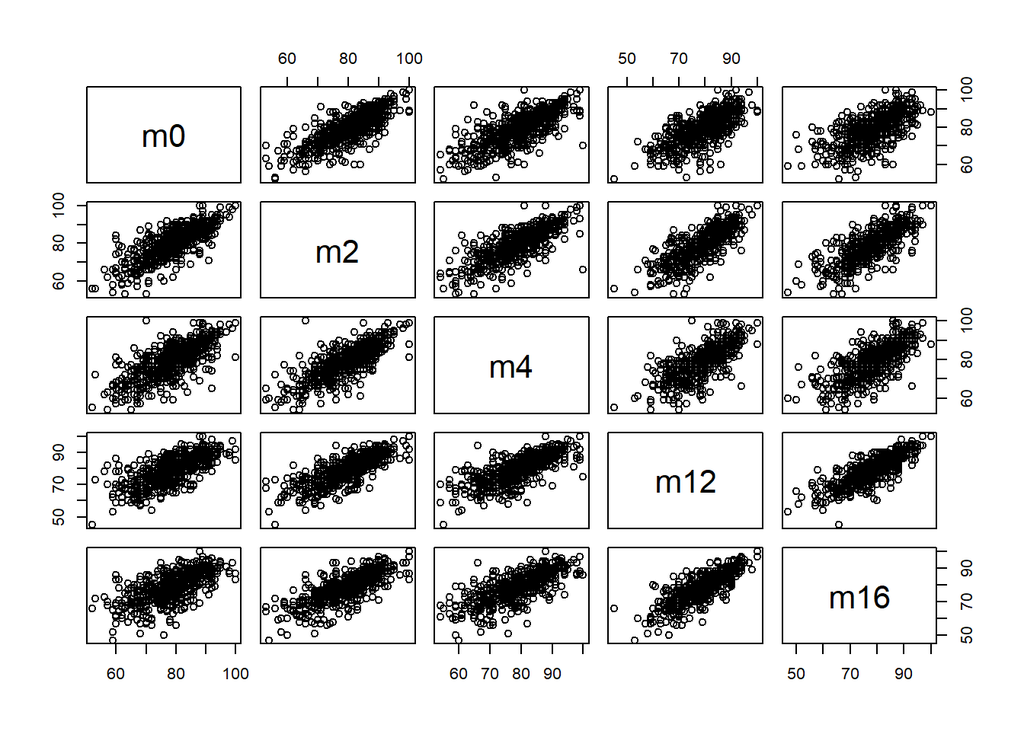

```r
pairs(campW[11:15])
```

## Based on Marginal and Conditional Residuals

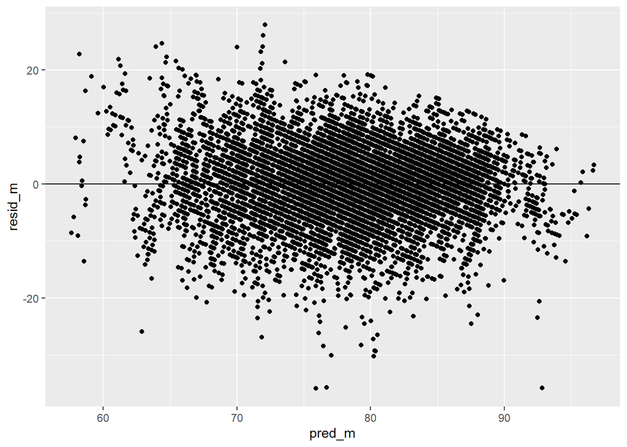

```r
# Marginal residuals
camp2$pred_m <- predict(camp2.RIRS.reduced, level = 0)

## Predicted Marginal Mean by Marginal Residuals
camp2$resid_m <- camp2$FFratio - camp2$pred_m
  ggplot(data = camp2,
  mapping = aes(x = pred_m, y = resid_m)) +
  geom_point() + geom_hline(yintercept=0)
```

## QQplot at each time point

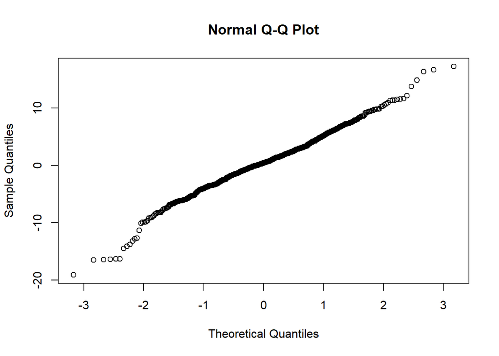

```r
qqnorm(camp2$resid_m[camp2$Visitc==2])
```

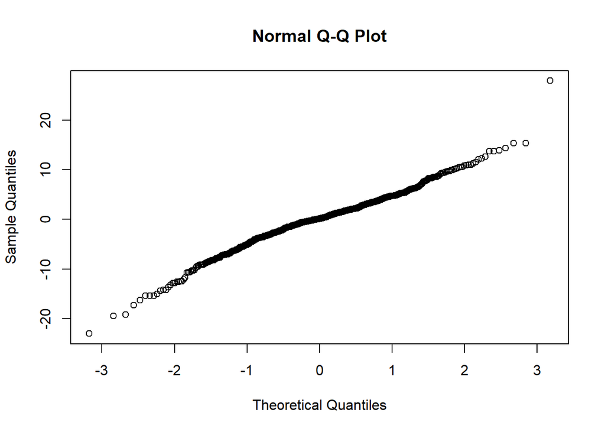

```r
qqnorm(camp2$resid_m[camp2$Visitc==4])
```

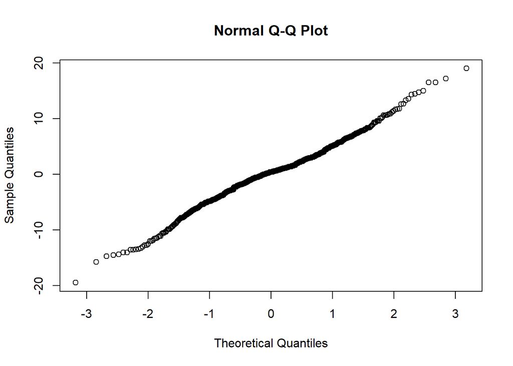

```r
qqnorm(camp2$resid_m[camp2$Visitc==12])
```

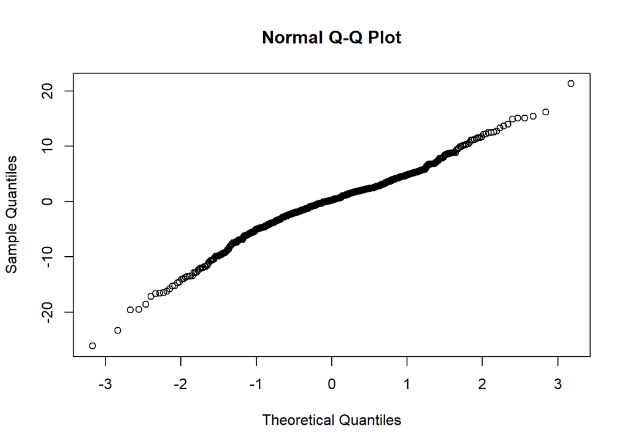

```r
qqnorm(camp2$resid_m[camp2$Visitc==16])
```

Checked normaility assumption for selected timepoints.

## Transformed Residuals

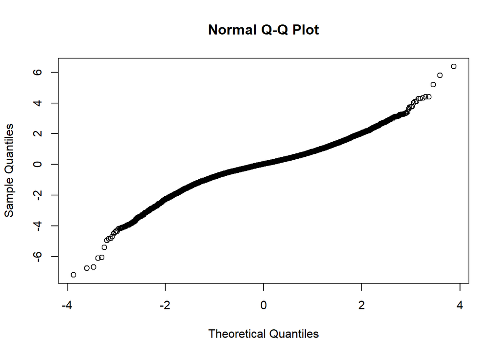

```r
est.cov <- extract.lme.cov(camp2.RIRS.reduced)
li <- t(chol(est.cov))
camp2$cholesky.residuals <- solve(li) %*% camp2$resid_m

## QQ plot of Transformed Residuals
qqnorm(camp2$cholesky.residuals)
```

```r
camp2$cholesky.residuals[1:20]
```

```
##  [1] -0.29770804  0.86119709  1.04368735 -0.09921899  0.82368761 -0.48463067
##  [7] -0.39563369  0.36720068 -0.61047423 -0.01167257 -0.41657955 -0.26532227
## [13] -0.11821944 -0.03665483 -2.24573002 -0.24071667  1.78170090 -1.78643463
## [19]  2.18490875  4.01576953
```

```r
camp2$cholesky.pred <- solve(li) %*% camp2$pred_m
camp2$cholesky.pred[1:20]
```

```
##  [1] 13.7735493  7.7967091  5.5341956  4.2520902  3.3855817  2.6873801
##  [7]  2.0207605  1.5460549  1.0228855  0.3820205 -0.1269923 -0.4317737
## [13] -0.7873245 -0.8319731 12.7449065  7.1953375  5.1274870  3.9568051
## [19]  3.1689996  2.5337201
```

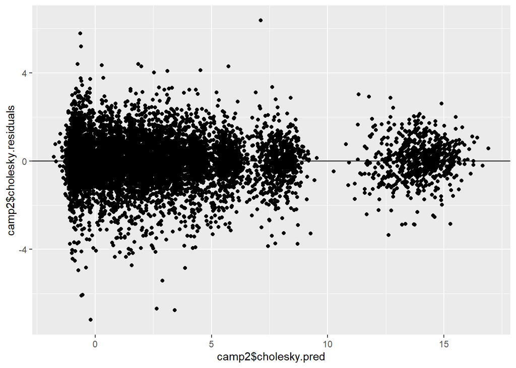

```r
## Transformed Predicted Value by Transformed Residuals
ggplot(mapping = aes(x = camp2$cholesky.pred, y = camp2$cholesky.residuals)) + geom_point() + geom_hline(yintercept=0)
```

```r
mean(abs(camp2$cholesky.residuals))
```

```
## [1] 0.7148769
```

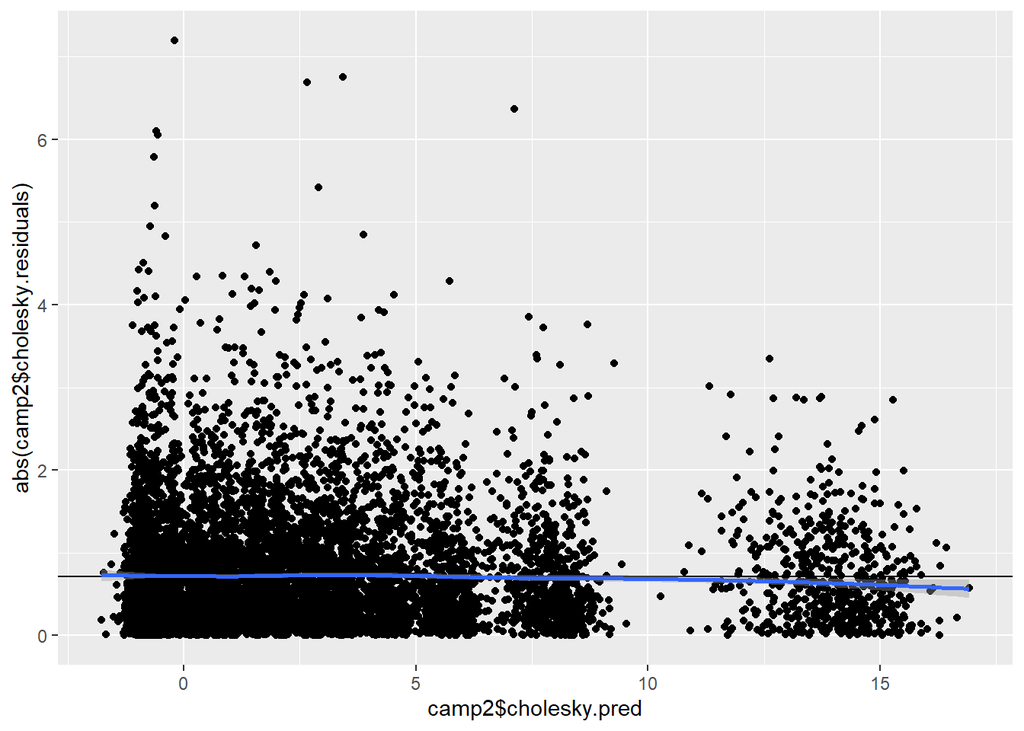

```r
## Absolute transformed residuals vs. transformed predicted value
ggplot(mapping = aes(x = camp2$cholesky.pred, y = abs(camp2$cholesky.residuals))) + geom_point() + geom_hline(yintercept=0.7148769) +
                 geom_smooth(method = "loess")
```

## Identify outlying subjects using Mahalanobis distance

```r
camp2$cholesky.residuals.sq <-  camp2$cholesky.residuals^2
Mdistance <-camp2 %>%
   group_by(id) %>%
  summarise(sum = sum(cholesky.residuals.sq), n = n())

Mdistance$pvalue <- pchisq(Mdistance$sum, df = Mdistance$n, ncp = 0, lower.tail = FALSE)
Mdistance$id[Mdistance$pvalue < 0.0001]
```

```
##  [1]    2   86  100  197  285  321  366  373  384  401  404  441  499  531  553
## [16]  557  561  587  639  659  686  722  744  764  771  788  790  796  809  819
## [31]  879  902  910 1005 1019 1024 1038
```

refit the model after excluding these observations

```r
iexclude = c(2, 86, 100, 197, 285, 321, 366, 373, 384, 401, 404, 441, 499, 531, 553, 557, 561, 587, 639, 659, 686, 722, 744, 764, 771, 788, 790, 796, 809, 819, 879, 902, 910, 1005, 1019, 1024, 1038)
"%ni%" = Negate( "%in%" )
camp4 = filter(camp2, camp2$id %ni% iexclude)

# Refit the model
camp4.RIRS.reduced <- lme(FFratio ~ Trtment*Fyears + BFFratio,
                   data = camp4,
                   random = ~1+Fyears|id,
                   method = "REML",
                   na.action = na.omit
                   )
summary(camp4.RIRS.reduced)
```

```
## Linear mixed-effects model fit by REML
##   Data: camp4
##        AIC      BIC    logLik
##   49690.03 49767.85 -24834.02
##
## Random effects:
##  Formula: ~1 + Fyears | id
##  Structure: General positive-definite, Log-Cholesky parametrization
##             StdDev    Corr
## (Intercept) 4.0164349 (Intr)
## Fyears      0.7133156 -0.121
## Residual    3.5200650
##
## Fixed effects:  FFratio ~ Trtment * Fyears + BFFratio
##                               Value Std.Error   DF  t-value p-value
## (Intercept)               20.684054 1.6515357 8076 12.52413  0.0000
## Trtment1nedocromil         0.011727 0.4111233  651  0.02852  0.9773
## Trtment2budesonide         2.736189 0.4111574  651  6.65485  0.0000
## Fyears                    -0.146751 0.0512522 8076 -2.86331  0.0042
## BFFratio                   0.734513 0.0203205  651 36.14640  0.0000
## Trtment1nedocromil:Fyears  0.070827 0.0781501 8076  0.90630  0.3648
## Trtment2budesonide:Fyears -0.309158 0.0775914 8076 -3.98443  0.0001
##  Correlation:
##                           (Intr) Trtmn1 Trtmn2 Fyears BFFrat Trt1:F
## Trtment1nedocromil        -0.132
## Trtment2budesonide        -0.149  0.437
## Fyears                    -0.040  0.160  0.160
## BFFratio                  -0.986  0.024  0.041  0.001
## Trtment1nedocromil:Fyears  0.027 -0.242 -0.105 -0.656 -0.001
## Trtment2budesonide:Fyears  0.027 -0.106 -0.243 -0.661 -0.001  0.433
##
## Standardized Within-Group Residuals:
##         Min          Q1         Med          Q3         Max
## -4.87674596 -0.46677337  0.03716561  0.52354671  3.56146865
##
## Number of Observations: 8734
## Number of Groups: 655
```

There are 37 outlying subjects. After exclusion, the model coefficients and conclusions are similar to the full sample.